# Calculating Dissimilarity Metrics Across Space and Time NULL MODEL

- This project is a collaborative effort to describe changes in taxonomic composition of fish communities around the world–as sampled by bottom trawl surveys.
- Code by Zoë J. Kitchel

```r
library(data.table)
library(vegan)
library(sf)
library(concaveman) #polygon around points
library(betapart) #allows us to partition beta diversity
library(geosphere)
library(ggpubr) #stat_regline_equation
library(nlme)


FishGlob_clean <- readRDS(here::here("data", "cleaned", "FishGlob.wellsampledyearscells_complete.final.rds"))
```

Are any survey_units missing CPUE?

```r
View(FishGlob_clean[, .(sum(is.na(wgt_cpue)),.N,(round(sum(is.na(wgt_cpue))/.N*100,1))), survey_unit])
```

Survey Season: NAs for wgt_cpue MEDITS: 350911 (no weights, only abundances, use abundances (num_cpue) instead?)

Otherwise, very small proportions, so will just exclude these observations.

Delete these observations above except for MEDITS (we will do trends in abundance metrics for this region)

```r
#delete all rows where wgt_cpue is NA,  unless it is MEDITS region
FishGlob_clean.noNA <- FishGlob_clean[(survey != "MEDITS" & !is.na(wgt_cpue)) | survey == "MEDITS"]

#check
summary(FishGlob_clean.noNA[, wgt_cpue]) #why inf? 13 observations from GSL-N,  I will delete these
```

```
   Min. 1st Qu.  Median    Mean 3rd Qu.    Max.    NA's
    0.0     3.9    24.1     Inf   151.8     Inf  350911
```

```r
FishGlob_clean.noNA <- copy(FishGlob_clean.noNA)[!is.infinite(wgt_cpue), ]
```

Loop through all regions (takes 6+ hours to run)

```r
all_survey_units <- unique(FishGlob_clean.noNA[, survey_unit])
```

For NZ-CHAT, we want to lump December observations with next year of observations (January, February)

```r
FishGlob_clean.noNA[survey_unit == "NZ-CHAT" & month == 12,  year := year+1, ]
```

Quick data set characteristics

```r
#number of hauls
nrow(unique(FishGlob_clean.noNA[,.(haul_id)]))
```

```
[1] 218172
```

```r
nrow(unique(FishGlob_clean.noNA[,.(accepted_name)]))
```

```
[1] 2044
```

```r
sort(unique(FishGlob_clean.noNA$year))
```

```
 [1] 1968 1969 1970 1971 1972 1982 1983 1984 1985 1986 1987 1988 1989 1990 1991 1992 1993 1994 1995 1996 1997
[22] 1998 1999 2000 2001 2002 2003 2004 2005 2006 2007 2008 2009 2010 2011 2012 2013 2014 2015 2016 2017 2018
[43] 2019 2020 2021
```

Some spp are duplicated within a haul. In all cases, this is due to verbatim names matching to a single accepted name. Therefore, we will sum these wgts and abundances

```r
FishGlob_clean.noNA[, wgt := sum(wgt,  na.rm = T), .(accepted_name,  haul_id)][,
                     wgt_h := sum(wgt_h,  na.rm = T), .(accepted_name,  haul_id)][,
                     wgt_cpue := sum(wgt_cpue,  na.rm = T), .(accepted_name,  haul_id)][,
                     num := sum(num,  na.rm = T), .(accepted_name,  haul_id)][,
                     num_h := sum(num_h,  na.rm = T), .(accepted_name,  haul_id)][,
                     num_cpue := sum(num_cpue,  na.rm = T), .(accepted_name,  haul_id)]

FishGlob_clean.noNA <- unique(FishGlob_clean.noNA[,.(survey, haul_id, country, sub_area, continent, stat_rec, station, stratum, year, month, day, quarter, season, latitude, longitude, haul_dur, area_swept, gear, depth, sbt, sst, num, num_h, num_cpue, wgt, wgt_h, wgt_cpue, verbatim_aphia_id, accepted_name, aphia_id, SpecCode, kingdom, phylum, class, order, family, genus, rank, survey_unit, years_sampled, cell_ID, cell_year_count, year_cell_count, years_sampled_update)])
```

#3) Null Model -randomize haulids

Calculate Beta Dissimilarity between all sampling sites within every survey unit

```r
    for (i in 26:length(all_survey_units)) {

      FishGlob_clean_subset <- FishGlob_clean.noNA[survey_unit == all_survey_units[i], ]

      #map
      ####unique lat lon
      #add column with adjusted longitude for few surveys that cross dateline (NZ-CHAT and AI)
      FishGlob_clean_subset[,longitude_adj := ifelse((survey_unit %in% c("AI","NZ-CHAT") & longitude > 0),longitude-360,longitude)]

        lat_lon <- unique(FishGlob_clean_subset[, .(latitude,  longitude_adj)])

       #list years
      FishGlob_clean_subset[, year:= as.numeric(year)] #make numeric
      setorder(FishGlob_clean_subset,  year)
      years <- unique(FishGlob_clean_subset[, year])

      #haul id keys
      haul_ids <- unique(FishGlob_clean_subset[, haul_id])
      haul_ids_key <- data.table(haul_id = haul_ids,  key_ID = seq(1, length(haul_ids),  by = 1))


      #convert haul_ids to numeric key_ids
      FishGlob_clean_subset <- FishGlob_clean_subset[haul_ids_key,  on = "haul_id"]

              for (j in 1:length(years)) {
                reduced_year <- FishGlob_clean_subset[year == years[j], ]

                # reshuffle haulids
                key_ID <- unique(reduced_year$key_ID)

                key_ID_shuffle <- sample(key_ID, size = length(key_ID))

                key_join <- data.table(key_ID = key_ID, key_ID_shuffle = key_ID_shuffle)

                #add new randomly generated key_ID_shuffles to main DT
                reduced_year <- reduced_year[key_join, on = "key_ID"]

                #distances among cells
                 setorder(reduced_year,  key_ID_shuffle)

                latitude_longitude_haul_id <- unique(reduced_year[, .(latitude, longitude, key_ID_shuffle)])
                distances <- distm(latitude_longitude_haul_id[, .(longitude, latitude)])
                key_IDs_shuffled <- latitude_longitude_haul_id[, key_ID_shuffle]

                colnames(distances) <- rownames(distances) <- key_IDs_shuffled

                #wide to long
                haul_id_distances.l <- reshape2::melt(distances, varnames = (c("haul_id1",  "haul_id2")),  value.name = "distance")

                #make into data table
                haul_id_distances.l <- data.table(haul_id_distances.l)

              if(!(reduced_year[1, survey] == "MEDITS")) {

                #if some rows have wgt_cpue missing,  get rid of these rows
                reduced_year <- reduced_year[complete.cases(reduced_year[, wgt_cpue]), ]

                  reduced_year_wide <- dcast(reduced_year,  key_ID_shuffle + year ~ accepted_name,  value.var = "wgt_cpue",  fun.aggregate = sum) #longitude to wide data for community matrix,  column names are cell then species


                  ncols <- ncol(reduced_year_wide)
                  communitymatrix <- reduced_year_wide[, 3:ncols] #community matrix

                  #list of haul_id keys
                  key_IDs_shuffled_subset <- reduced_year_wide[,key_ID_shuffle]

                  dissimilarities_abundance <- beta.pair.abund(communitymatrix,  index.family = "bray") #dissimilarity

                  #make into matrix
                  dissimilarities_abundance_total.m <- as.matrix(dissimilarities_abundance$beta.bray,  labels=TRUE) #total


                  colnames(dissimilarities_abundance_total.m) <- rownames(dissimilarities_abundance_total.m) <- key_IDs_shuffled_subset


                  #reshape dissimilarities
                 dissimilarities_abundance_total.l <- reshape2::melt(dissimilarities_abundance_total.m,  varnames = c("haul_id1",  "haul_id2"),  value.name = "bray_curtis_dissimilarity_total")


                  #and then to data table format
                  dissimilarities_abundance_total.l <- data.table(dissimilarities_abundance_total.l)

                  #delete if haulid1 == haulid2
                  dissimilarities_abundance_total.l <- dissimilarities_abundance_total.l[!(haul_id1==haul_id2),]

                  #add year for these values

                  dissimilarities_abundance_total.l[,  "year" := years[j]]

                  #what type of metric?
                  dissimilarities_abundance_total.l[, "abund_biomass" := "biomass"]

                  #merge distance with dissimilarity for this year with both metrics of dissimilarity
                  dissimilarities_full <- haul_id_distances.l[dissimilarities_abundance_total.l,  on = c("haul_id1",  "haul_id2")]

                  #add survey survey unit
                  dissimilarities_full[, "survey" := FishGlob_clean_subset[1, survey]]
                  dissimilarities_full[, "survey_unit" := all_survey_units[i]]

                  #add to data table
                  distances_dissimilarities_allyears <- rbind(distances_dissimilarities_allyears,  dissimilarities_full)

                  print(paste0(j, "/", length(years)))

              } else { #if we do using abundance instead

                #if some rows have num_cpue missing,  get rid of these rows
                reduced_year <- reduced_year[complete.cases(reduced_year[, num_cpue]), ]

                  reduced_year_wide <- dcast(reduced_year,  key_ID_shuffle + year ~ accepted_name,  value.var = "num_cpue",  fun.aggregate = sum) #longitude to wide data for community matrix,  column names are cell then species


                  ncols <- ncol(reduced_year_wide)
                  communitymatrix <- reduced_year_wide[, 3:ncols] #community matrix
                  communitymatrix.occurence <- communitymatrix
                  communitymatrix.occurence[communitymatrix.occurence > 0] <- 1

                  #list of haul_id keys
                  key_IDs_subset <- reduced_year_wide[,key_ID_shuffle]

                  dissimilarities_abundance <- beta.pair.abund(communitymatrix,  index.family = "bray") #dissimilarity

                  #make into matrix
                   dissimilarities_abundance_total.m <- as.matrix(dissimilarities_abundance$beta.bray,  labels=TRUE) #total


                     colnames(dissimilarities_abundance_total.m) <- rownames(dissimilarities_abundance_total.m) <- key_IDs_subset


                  #reshape dissimilarities
                  dissimilarities_abundance_total.l <- reshape2::melt(dissimilarities_abundance_total.m,  varnames = c("haul_id1",  "haul_id2"),  value.name = "bray_curtis_dissimilarity_total")

                  #and then to data table format
                   dissimilarities_abundance_total.l <- data.table(dissimilarities_abundance_total.l)

                  #add year for these values

                  dissimilarities_abundance_total.l[,  "year" := years[j]]

                  #what type of metric?
                    dissimilarities_abundance_total.l[, "abund_biomass" := "abund"]

                  #merge distance with dissimilarity for this year with both metrics of dissimilarity
                  dissimilarities_full <- haul_id_distances.l[dissimilarities_abundance_total.l,  on = c("haul_id1",  "haul_id2")]

                  #add survey survey unit
                  dissimilarities_full[, "survey" := FishGlob_clean_subset[1, survey]]
                  dissimilarities_full[, "survey_unit" := all_survey_units[i]]

                  #add to data table
                  distances_dissimilarities_allyears <- rbind(distances_dissimilarities_allyears,  dissimilarities_full)

                  print(paste0(j, "/", length(years)))

                  } #closes if else abundance versus biomass


             } #closes year

      print(paste0("We have cycled through ",  i, " of ", length(all_survey_units),  " total survey/season combos"))

      } #closes survey/region
```

```
[1] "1/16"
[1] "2/16"
[1] "3/16"
[1] "4/16"
[1] "5/16"
[1] "6/16"
[1] "7/16"
[1] "8/16"
[1] "9/16"
[1] "10/16"
[1] "11/16"
[1] "12/16"
[1] "13/16"
[1] "14/16"
[1] "15/16"
```

[output cut: 372 more lines]

Quick plot

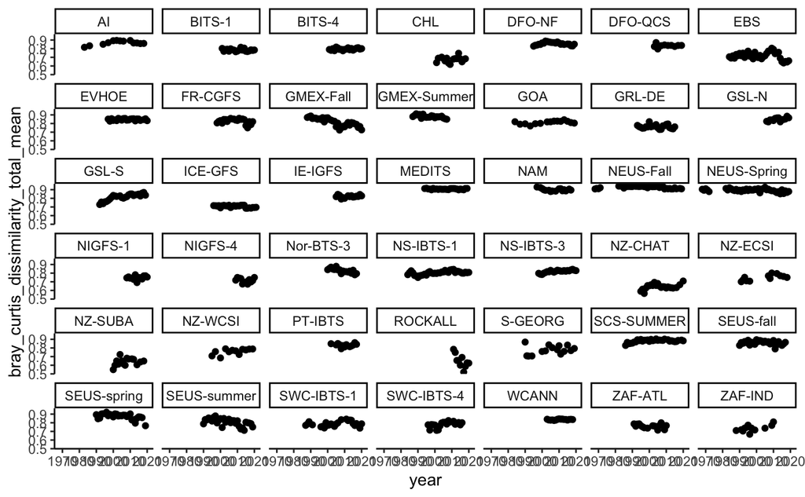

Take yearly mean of each value

Some regions have NAs, not sure why SCS-SUMMER 89-94 DFO-QCS 2013 NEUS-Spring NEUS-Fall

For now, do NA.RM = T, but at some point I need to figure out why we have NAs to begin with in distances_dissimilarities_allyears

```r
distances_dissimilarities_allyears[, bray_curtis_dissimilarity_balanced_mean := mean(bray_curtis_dissimilarity_balanced, na.rm = T),.(survey_unit,year)][, bray_curtis_dissimilarity_gradient_mean := mean(bray_curtis_dissimilarity_gradient, na.rm = T),.(survey_unit,year)][, bray_curtis_dissimilarity_total_mean := mean(bray_curtis_dissimilarity_total, na.rm = T),.(survey_unit,year)][, jaccard_dissimilarity_turnover_mean := mean(jaccard_dissimilarity_turnover, na.rm = T),.(survey_unit,year)][, jaccard_dissimilarity_nestedness_mean := mean(jaccard_dissimilarity_nestedness, na.rm = T),.(survey_unit,year)][, jaccard_dissimilarity_total_mean := mean(jaccard_dissimilarity_total, na.rm = T),.(survey_unit,year)]

distances_dissimilarities_allyears.r <- unique(distances_dissimilarities_allyears[,.(survey, survey_unit, year,abund_biomass, bray_curtis_dissimilarity_balanced_mean, bray_curtis_dissimilarity_gradient_mean, bray_curtis_dissimilarity_total_mean, jaccard_dissimilarity_turnover_mean, jaccard_dissimilarity_nestedness_mean, jaccard_dissimilarity_total_mean)])

rm(distances_dissimilarities_allyears)


saveRDS(distances_dissimilarities_allyears.r,  here::here("output", "distance_decay", "distances_dissimilarities_allyears.r.rds"))
```

Box plot for each region

```r
box_plots_jaccard <- list()
box_plots_bray <- list()

bray_model_outputs <- data.table()

bray_model_outputs <- as.data.table(matrix(nrow = length(all_survey_units)))
bray_model_outputs[,  survey:=as.character(V1)][,  season:=as.character(V1)][,  season_survey:=as.character(V1)][,  bray_coef:=as.numeric(V1)][,  bray_intercept := as.numeric(V1)][, bray_coef_pvalue := as.numeric(V1)][, bray_r_squared := as.numeric(V1)]
bray_model_outputs[,  V1 := NULL]

jaccard_model_outputs <- as.data.table(matrix(nrow = length(all_survey_units)))

jaccard_model_outputs <- as.data.table(matrix(nrow = length(all_survey_units)))
jaccard_model_outputs[,  survey:=as.character(V1)][,  season:=as.character(V1)][,  season_survey:=as.character(V1)][,  jaccard_coef:=as.numeric(V1)][,  jaccard_intercept := as.numeric(V1)][, jaccard_coef_pvalue := as.numeric(V1)][, jaccard_r_squared := as.numeric(V1)]
jaccard_model_outputs[,  V1 := NULL]


distances_dissimilarities_allyears[, year_f := as.factor(year)]

#in case you didn't make it earlier
all_survey_units <- unique(distances_dissimilarities_allyears[, survey_unit])

for (i in 1:length(all_survey_units)) {
      distances_dissimilarities_allyears_subset <- distances_dissimilarities_allyears[season_survey == all_survey_units[i]]

    #jaccard similarity
#    box_plots_jaccard[[i]] <- ggplot(distances_dissimilarities_allyears_subset, aes(year_f,  #jaccard_dissimilarity_turnover)) +
#      geom_boxplot(outlier.shape = NA,  lwd = 0.2) +
#      labs(x="Year",  y = "Jaccard Dissimilarity") +
#      geom_smooth(method = "lm",  se=FALSE,  color="red",  aes(group=1),  lwd = 0.3) +
#      stat_regline_equation() +
#      theme_classic() +
#      theme(axis.text.x = element_text(angle = 90))
#
#    #bray curtis similarity
#    box_plots_bray[[i]] <- ggplot(distances_dissimilarities_allyears_subset, aes(year_f, bray_curtis_dissimilari#ty_balanced)) +
#      geom_boxplot(outlier.shape = NA,  lwd = 0.2) +
#      labs(x="Year",  y = "Bray Curtis Dissimilarity") +
#      geom_smooth(method = "lm",  se=FALSE,  color="red",  aes(group=1),  lwd = 0.3) +
#      stat_regline_equation() +
#      theme_classic() +
#      theme(axis.text.x = element_text(angle = 90))
    #START HERE GET THESE TO ACTUALLY SAVE
    #corresponding models
    avg_jaccard_mod <- lm(data = distances_dissimilarities_allyears_subset,  formula = jaccard_dissimilarity_turnover ~ as.numeric(year))

    jaccard_model_outputs[i,  "survey"] <- distances_dissimilarities_allyears_subset[1,  survey]
    jaccard_model_outputs[i,  "season"] <- distances_dissimilarities_allyears_subset[1,  season]
    jaccard_model_outputs[i,  "season_survey"] <- distances_dissimilarities_allyears_subset[1,  season_survey]

    #coef

    jaccard_model_outputs[i, "jaccard_coef"] <- avg_jaccard_mod$coefficients[[2]]

    #intercept
    jaccard_model_outputs[i, "jaccard_intercept"] <- avg_jaccard_mod$coefficients[[1]]

    #p-value
     jaccard_model_outputs[i, "jaccard_coef_pvalue"] <- summary(avg_jaccard_mod)$coefficients[2, 4]

    #R^2
    jaccard_model_outputs[i, "jaccard_r_squared"] <- summary(avg_jaccard_mod)$r.squared

    #bray

    avg_bray_mod <- lm(data = distances_dissimilarities_allyears_subset,  formula = bray_curtis_dissimilarity_balanced ~ as.numeric(year))

    bray_model_outputs[i,  "survey"] <- distances_dissimilarities_allyears_subset[1,  survey]
    bray_model_outputs[i,  "season"] <- distances_dissimilarities_allyears_subset[1,  season]
    bray_model_outputs[i,  "season_survey"] <- distances_dissimilarities_allyears_subset[1,  season_survey]

    #coef

    bray_model_outputs[i, "bray_coef"] <- avg_bray_mod$coefficients[[2]]
    #intercept
    bray_model_outputs[i, "bray_intercept"] <- avg_bray_mod$coefficients[[1]]

    #p-value
    bray_model_outputs[i, "bray_coef_pvalue"] <- summary(avg_bray_mod)$coefficients[2, 4]

    #R^2
    bray_model_outputs[i, "bray_r_squared"] <- summary(avg_bray_mod)$r.squared



}



#save plots and models as objects
saveRDS(jaccard_model_outputs,  here::here("output", "distance_decay", "jaccard_model_outputs.rds"))
saveRDS(bray_model_outputs,  here::here("output", "distance_decay", "bray_model_outputs.rds"))

saveRDS(box_plots_jaccard,  here::here("output", "distance_decay", "box_plots_jaccard.rds"))
saveRDS(box_plots_bray,  here::here("output", "distance_decay", "box_plots_bray.rds"))

#save plots as images

for (i in 1:length(all_survey_units)) {
  filename_jaccard <- paste0(all_survey_units[i],  "_jaccard_box_plot.jpg")
  ggsave(box_plots_jaccard[[i]],  path = here::here("figures",  "distance_decay"),  filename = filename_jaccard)

  filename_bray <- paste0(all_survey_units[i],  "_bray_box_plot.jpg")
  ggsave(box_plots_bray[[i]],  path = here::here("figures",  "distance_decay"),  filename = filename_bray)
}
```

Overall slope

Dornelas 2014: “To estimate the global long-term trends in diversity, to each of the 14 metrics (10 community structure and 4 composition turnover metrics),

- we first fit a linear model with a single slope but a different intercept and a residual variance for each time series, by using generalized least squares (GLS). Additionally,
- we fit a linear model to each time series allowing a different slope and an intercept, by using ordinary least squares (OLS).

The R squared value and the p-value of each slope coefficient (the OLS estimate) are also calculated. However, the provided p-value may be overly confident due to the unknown correlated structure so a careful interpretation is required. These statistics are included to provide intuitive information of the fitted linear trend of each time series, rather than in a classical hypothesis-testing context.”

GLS: John Fox & Sanford Weisberg 2019 https://socialsciences.mcmaster.ca/jfox/Books/Companion/appendices/Appendix-Timeseries-Regression.pdf - The gls() function in the nlme package (Pinheiro et al., 2018),

Linear model with single slope but different interceept and residual variance for each time series

First, just linear model

```r
overall_mod <- gls(bray_curtis_dissimilarity_balanced ~ year + season_survey,  data = distances_dissimilarities_allyears)
```

Averages for each survey_unit

```r
colnames(distances_dissimilarities_allyears)


distances_dissimilarities_allyears[, mean_jaccard := mean(jaccard_dissimilarity_turnover),  .(survey,  season,  year)]
distances_dissimilarities_allyears[, mean_bray := mean(bray_curtis_dissimilarity_balanced),  .(survey,  season,  year)]
```